# Estimation of Moon’s Distance Anchored Differently by Earth’s Radius and Sun’s Distance

# Abstract

# Background

As a teacher, I wanted a robust controlled experiment I could run in a small class. I originally tried the experiment from Amos Tversky and Daniel Kahneman of asking for estimates of either $1\times 2\times 3\times 4\times 5\times 6\times 7\times 8$ or the equivalent product $8\times 7\times 6\times 5\times 4\times 3\times 2\times 1$. However, in my classes, the estimates had large variation and detecting a significant difference was not possible with such a small sample (data omitted). In my experience, people tend to have poor knowledge of the vast differences of magnitudes in nature. I figured that anchors with very different magnitudes would create a more rubust effect. I also wanted the anchors and estimations to be of something most people were conceptually familiar with. Thus I used the radius of Earth and distance to Sun as anchors and the distance to the moon for the estimated value.

To interpret the results, hypothesis testing is used to determine a $p$-value. Statistical inference often assumes sampling distributions are normal. This condition is easily met with moderate sample sizes from nearly any population (even with a population as unnormal as bimodal or exponential distributions). However, with small sample sizes, the normal approximation to sampling distributions easily fails. Luckily, permutation tests are more rubust and, with a modern version of R, intuitive to code.

# Experimental Methods

Every participant was asked to estimate the distance to the moon. By having the instructions on cards, and asking the responses to be written on the cards, all participants could participate simultaneously without effecting each other. The participants were given approximately 30 seconds to write an answer. All participants responded.

Two types of card gave different hints. The groups (Earth and Sun) were randomly assigned by shuffling the cards. By using cards, it was easy to guarantee approximately equal sample sizes. Half of the participants were told the radius of Earth while the other half were told the distance to the Sun. The cards were made with the printout that can be generated (or modified) with the R script below.

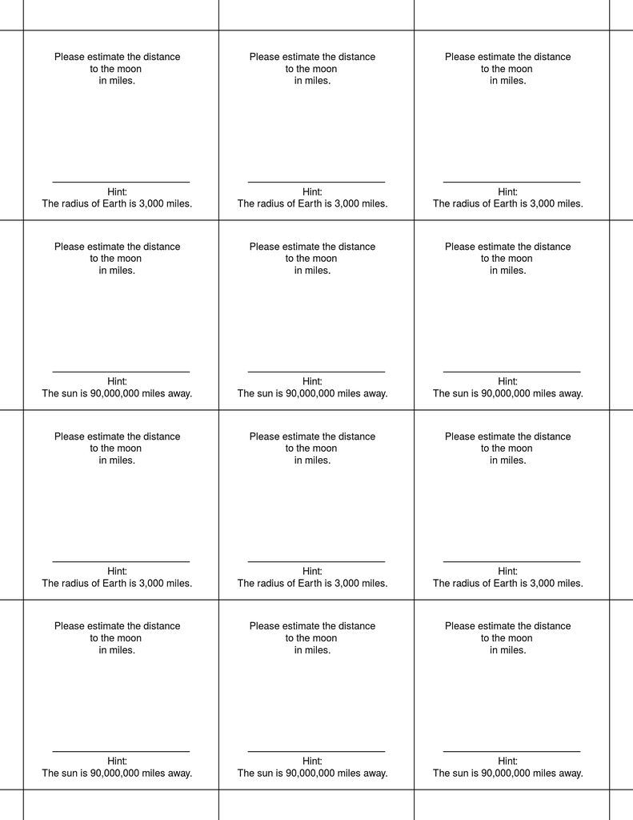

```r
#This code will create a page that can be printed (saved in the current working directory).
#The resulting pdf/printout is included at the end of this article.
pdf("Moon_cards.pdf",width=8.5,height=11,paper="letter",title = "Moon cards printout")
par(mar = c(0,0,0,0))
plot.new()
fig.align="center"
for(xpos in seq(0,1,1/3)){ abline(v = xpos) }
for(ypos in seq(0,1,1/4)){ abline(h = ypos) }
for(x in seq(0,2/3,1/3)){
  for(y in seq(0,3/4,1/4)){
    text(x+0.16,y+0.20,"Please estimate the distance\nto the moon \nin miles.", cex=0.8)
  lines(c(x+0.05,x+0.3333-0.05),c(y+0.07,y+0.07))
  if (y %in% c(0,0.5)){
    text(x+0.16,y+0.03,"Hint:\nThe sun is 90,000,000 miles away.", cex=0.8)
  } else {
    text(x+0.16,y+0.03,"Hint:\nThe radius of Earth is 3,000 miles.", cex=0.8)
  }
  }
}
dev.off()
```

Because the cards were shuffled, I was blind to the treatments. The students did not know what the other cards said, so they were also blind to their treatment. Thus, this experiment was effectively double-blind.

# Results

The data showed a strong right skew in both groups.

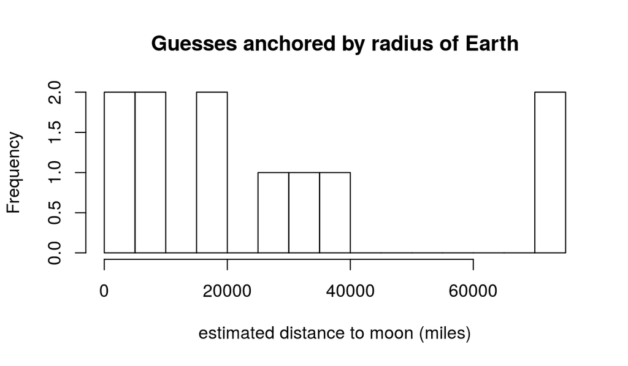

```r
earth = c(7.5e4,2e4,39590,299,3900,75000,30000,8197,15836,8100,35000)
sun = c(1.23e7,1.85e5,2.2e5,45730003,1.2e5,6e5,4e8,2.05e7,48372213,3e5)
hist(earth,breaks=20, xlab = "estimated distance to moon (miles)",
     main = "Guesses anchored by radius of Earth")
```

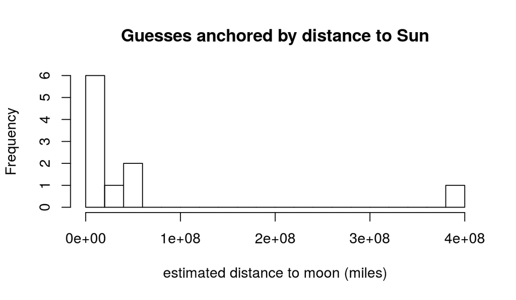

```r
hist(sun,breaks=20, xlab = "estimated distance to moon (miles)",
     main = "Guesses anchored by distance to Sun")
```

The heavy skew along with small sample size should make us wary of using an approach that assumes (repeated) small samples would be normally distributed. We continue with the Welch’s $t$ test as an exercise, even though we recognize it is not appropriate.

We find the means and sample standard deviations.

```r
n1 = length(earth)
xbar1 = mean(earth)
s1 = sd(earth)
n2 = length(sun)
xbar2 = mean(sun)
s2 = sd(sun)
```

| Group | Mean | Standard deviation | Size |
| --- | --- | --- | --- |
| Earth | $2.83\times 10^{4}$ | $2.64\times 10^{4}$ | $11$ |
| Sun | $5.28\times 10^{7}$ | $1.23\times 10^{8}$ | $10$ |

We state the hypotheses.
$$H_0:~~~\mu_2-\mu_1=0$$
$$H_\text{A}:~~~\mu_2-\mu_1\ne 0$$
We find the degrees of freedom using the Welch-Satterthwaite equation.

```r
df = floor((s1^2/n1+s2^2/n2)^2/(s1^4/n1^2/(n1-1)+s2^4/n2^2/(n2-1)))
```

$$df = \frac{\left(\frac{(s_1)^2}{n_1}+\frac{(s_2)^2}{n_2} \right)^2}{\frac{(s_1)^4}{(n_1)^2(n_1-1)}+\frac{(s_2)^4}{(n_2)^2(n_2-1)}} = 9$$
We find the standard error.

```r
SE = sqrt(s1^2/n1+s2^2/n2)
```

$$SE = \sqrt{\frac{(s_1)^2}{n_1}+\frac{(s_2)^2}{n_2}} =3.9\times 10^{7}$$
We determine the observed test statistic.

```r
tobs = (xbar2-xbar1)/SE
```

$$t_\text{obs} = \frac{(\bar{x}_2-\bar{x}_1)-(\mu_2-\mu_1)_0}{SE} = 1.35$$
We can determine the two-tail $p$-value.

```r
pvalue = 2*pt(-abs(tobs),df)
```

$$p\text{-value} = 0.209$$
Notice, we can also check our work with R’s built-in function.

```r
t.test(earth,sun)
```

```
##
##  Welch Two Sample t-test
##
## data:  earth and sun
## t = -1.353, df = 9, p-value = 0.2091
## alternative hypothesis: true difference in means is not equal to 0
## 95 percent confidence interval:
##  -141093084   35484172
## sample estimates:
##   mean of x   mean of y
##    28265.64 52832721.60
```

The other test of significance is based on an exploration of the possible reshufflings of the given data. This type of significance test can be called an estimated permutation test, a randomization test, or a random permutation test.

```r
num_resamples = 100000
original_difference = xbar2-xbar1
resampling_differences = vector("numeric",num_resamples)
for(i in 1:num_resamples)
{
  tot1 = sum(sample(c(earth,sun),n1))
  tot2 = sum(c(earth,sun))-tot1
  mean1 = tot1/n1
  mean2 = tot2/n2
  resampling_differences[i] = mean2-mean1
}
signif(original_difference,2)
```

```
## [1] 5.3e+07
```

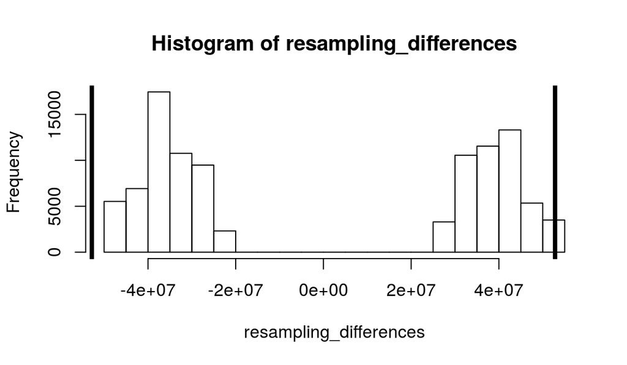

```r
hist(resampling_differences)
abline(v = original_difference, col = "black", lwd = 4)
abline(v = -original_difference, col = "black", lwd = 4)
```

```r
pvalue2 = sum(abs(resampling_differences)>=abs(original_difference))/num_resamples
```

$$p\text{-value} = 0$$

# Discussion

This experiment showed a causal link between the anchor and the estimation. The mechanism is unclear, but this behavior is at least similar to anchoring. I would suggest that beyond a simple anchoring theory, it might be useful to consider influency with orders of magnitudes. I know I spend a considerable amount of time trying to remember various orders of magnitudes, but I have a feeling this is not a hobby of many of my students.

It was not intentional to run an experiment that anchored in a nonstandard way. In the future, I plan to run the experiment by first asking participants whether they think the distance to the moon is more or less than an anchor and then asking for the estimate.

While thinking about this experiment, some new research questions arose. I wonder whether an anchor with more significant digits will have a stronger pull than an anchor with fewer significant digits. I wonder whether an inaccurate diagram (cartoon sun/earth/moon) would effect the results.